# Project 2: Top 5 Baby Names, 1926 to 2025

- Show All Code
- Hide All Code
- View Source

DATA 607 · Project 2 · Dataset 2 of 3

Author

Dillon Leeper

Published

October 11, 2026

## Overview

This dataset comes from a classmate’s Discussion 5A post. It’s the Social Security Administration’s list of the five most popular baby names for girls and boys in every year from 1926 through 2025. The question from the post: **which names stayed popular the longest, and do boys’ and girls’ names turn over at different rates?**

```r
library(tidyverse)   # reading, reshaping, and charting
library(knitr)       # kable() for tables
library(scales)      # number formatting

# Shared look for all three Project 2 datasets
theme_p2 <- function() {
  theme_minimal(base_size = 12) +
    theme(
      plot.title       = element_text(face = "bold"),
      panel.grid.minor = element_blank(),
      legend.position  = "top"
    )
}
sex_colors <- c("Girls" = "#c9701a", "Boys" = "#2c5f8a")
```

## Data source

Social Security Administration, [Top 5 Names in Each of the Last 100 Years](https://www.ssa.gov/oact/babynames/top5names.html), accessed October 11, 2026. I copied the HTML table into `ssa_top5_names_wide.csv` without changing its layout. The page has a two-level header: a top row with “Girls” over the first five name columns and “Boys” over the last five, and a second row with “Year” and then “Rank 1” through “Rank 5” twice. I kept both header rows in the CSV so the code has to rebuild them.

The page notes that Michael was the top boys’ name 44 times and Mary the top girls’ name 30 times. My copy matches both counts, which is a quick check that nothing was lost in the copy.

## Data structure before tidying

```r
csv_url <- paste0(
  "https://raw.githubusercontent.com/dillonleeper/",
  "DATA-607/main/assignments/week06/project2/baby-names/ssa_top5_names_wide.csv"
)

# Read every cell as text with no header, so both header rows come in as data.
# Try the GitHub copy first; fall back to the local copy if it can't be reached.
read_raw <- function(path) {
  read_csv(path, col_names = FALSE, col_types = cols(.default = col_character()))
}
raw_names <- tryCatch(read_raw(csv_url), error = function(e) read_raw("ssa_top5_names_wide.csv"))

head(raw_names, 5) |> kable(caption = "First five rows of the raw file, exactly as stored")
```

First five rows of the raw file, exactly as stored

| X1 | X2 | X3 | X4 | X5 | X6 | X7 | X8 | X9 | X10 | X11 |
| --- | --- | --- | --- | --- | --- | --- | --- | --- | --- | --- |
| NA | Girls | NA | NA | NA | NA | Boys | NA | NA | NA | NA |
| Year | Rank 1 | Rank 2 | Rank 3 | Rank 4 | Rank 5 | Rank 1 | Rank 2 | Rank 3 | Rank 4 | Rank 5 |
| 2025 | Olivia | Charlotte | Emma | Amelia | Sophia | Liam | Noah | Oliver | Theodore | Henry |
| 2024 | Olivia | Emma | Amelia | Charlotte | Mia | Liam | Noah | Oliver | Theodore | James |
| 2023 | Olivia | Emma | Charlotte | Amelia | Sophia | Liam | Noah | Oliver | James | Elijah |

The raw file has **102 rows** and **11 columns**: 2 header rows plus 100 years. Why it’s untidy:

- **Sex and rank are stored in the headers.** They’re two variables, but they only exist as column labels.
- **The header is split across two rows.** “Girls” and “Boys” appear once each, over blank cells, so R can’t name the columns on its own. Read normally, it would produce duplicate names like `Rank 1` and `Rank 1`.
- **Each row holds ten observations.** One row is one year, but it contains ten separate name-rank facts.

## Transformation steps

### Step 1: Rebuild the column names from the two header rows

The top header row only says “Girls” or “Boys” over the first column of each group, so `fill()` carries it across the blank cells. Then I combine it with the rank number into one snake_case name per column, like `girls_rank_1`.

```r
header <- tibble(
  sex  = unlist(raw_names[1, ]),
  rank = unlist(raw_names[2, ])
) |>
  fill(sex) |>   # "Girls" / "Boys" carried right over the blank cells
  mutate(col_name = if_else(
    is.na(sex),
    "year",
    paste(str_to_lower(sex), "rank", str_extract(rank, "\\d"), sep = "_")
  ))

header |> kable(caption = "How each column gets its new name")
```

How each column gets its new name

| sex | rank | col_name |
| --- | --- | --- |
| NA | Year | year |
| Girls | Rank 1 | girls_rank_1 |
| Girls | Rank 2 | girls_rank_2 |
| Girls | Rank 3 | girls_rank_3 |
| Girls | Rank 4 | girls_rank_4 |
| Girls | Rank 5 | girls_rank_5 |
| Boys | Rank 1 | boys_rank_1 |
| Boys | Rank 2 | boys_rank_2 |
| Boys | Rank 3 | boys_rank_3 |
| Boys | Rank 4 | boys_rank_4 |
| Boys | Rank 5 | boys_rank_5 |

### Step 2: Drop the header rows and apply the new names

```r
names_wide <- raw_names |>
  slice(-(1:2)) |>              # the two header rows are now in the names
  set_names(header$col_name)

head(names_wide, 3) |> kable()
```

| year | girls_rank_1 | girls_rank_2 | girls_rank_3 | girls_rank_4 | girls_rank_5 | boys_rank_1 | boys_rank_2 | boys_rank_3 | boys_rank_4 | boys_rank_5 |
| --- | --- | --- | --- | --- | --- | --- | --- | --- | --- | --- |
| 2025 | Olivia | Charlotte | Emma | Amelia | Sophia | Liam | Noah | Oliver | Theodore | Henry |
| 2024 | Olivia | Emma | Amelia | Charlotte | Mia | Liam | Noah | Oliver | Theodore | James |
| 2023 | Olivia | Emma | Charlotte | Amelia | Sophia | Liam | Noah | Oliver | James | Elijah |

### Step 3: Reshape wide to long

`pivot_longer()` turns the ten name columns into rows. Because each column name holds two variables, `names_pattern` pulls them apart: `girls_rank_1` becomes `sex = girls` and `rank = 1`.

```r
names_tidy <- names_wide |>
  pivot_longer(
    cols      = -year,
    names_to      = c("sex", "rank"),
    names_pattern = "(girls|boys)_rank_(\\d)",
    values_to     = "name"
  ) |>
  mutate(
    year = as.integer(year),
    rank = as.integer(rank),
    sex  = str_to_title(sex),    # "girls" -> "Girls"
    name = str_squish(name)      # remove any stray spaces from the copy
  ) |>
  arrange(year, sex, rank)

head(names_tidy, 10) |> kable(caption = "Tidy data: one row per year, sex, and rank")
```

Tidy data: one row per year, sex, and rank

| year | sex | rank | name |
| --- | --- | --- | --- |
| 1926 | Boys | 1 | Robert |
| 1926 | Boys | 2 | John |
| 1926 | Boys | 3 | James |
| 1926 | Boys | 4 | William |
| 1926 | Boys | 5 | Charles |
| 1926 | Girls | 1 | Mary |
| 1926 | Girls | 2 | Dorothy |
| 1926 | Girls | 3 | Betty |
| 1926 | Girls | 4 | Helen |
| 1926 | Girls | 5 | Margaret |

### Step 4: Check for missing or inconsistent values

There are no blanks in this table, but I check rather than assume. Every year should have exactly five girls’ names and five boys’ names, ranks 1 to 5, and no name should appear twice in the same year and sex.

```r
checks <- tibble(
  check  = c("Missing names",
             "Years without exactly 5 names per sex",
             "Same name twice in one year and sex",
             "Years covered"),
  result = c(
    sum(is.na(names_tidy$name) | names_tidy$name == ""),
    names_tidy |> count(year, sex) |> filter(n != 5) |> nrow(),
    names_tidy |> count(year, sex, name) |> filter(n > 1) |> nrow(),
    paste(min(names_tidy$year), "to", max(names_tidy$year))
  )
)
checks |> kable(col.names = c("Check", "Result"))
```

| Check | Result |
| --- | --- |
| Missing names | 0 |
| Years without exactly 5 names per sex | 0 |
| Same name twice in one year and sex | 0 |
| Years covered | 1926 to 2025 |

```r
stopifnot(
  !any(is.na(names_tidy$name)),
  all(count(names_tidy, year, sex)$n == 5)
)
```

All checks pass, so no rows needed fixing. The tidy table has **1000 rows** (100 years × 2 sexes × 5 ranks) and 4 columns.

## Analytical methods

All analysis uses `names_tidy`.

- **Streaks:** for each name and sex, I sort the years it appeared in the top five and start a new streak whenever there’s a gap. A streak’s length is the number of consecutive years. A name can have more than one streak if it dropped out and came back.
- **Turnover:** for each year after 1926, I count how many names in that year’s top five weren’t in the previous year’s top five. That’s the number of **new entries**. Summing new entries by sex, and by decade, shows how fast each list changes.
- **Variety:** the number of different names that ever reached the top five for each sex.

No part of this analysis uses randomness, so no seed is needed.

```r
streaks <- names_tidy |>
  arrange(sex, name, year) |>
  group_by(sex, name) |>
  mutate(streak_id = cumsum(c(1, diff(year) != 1))) |>   # new id after any gap
  group_by(sex, name, streak_id) |>
  summarise(
    start     = min(year),
    end       = max(year),
    years     = n(),
    best_rank = min(rank),
    .groups   = "drop"
  )

turnover <- names_tidy |>
  group_by(sex, year) |>
  summarise(top5 = list(name), .groups = "drop") |>
  arrange(sex, year) |>
  group_by(sex) |>
  mutate(new_entries = map2_int(
    top5, lag(top5),
    \(now, before) if (is.null(before)) NA_integer_ else length(setdiff(now, before))
  )) |>
  ungroup()
```

## Analysis 1: Which names stayed popular the longest?

```r
longest <- streaks |> arrange(desc(years), start) |> slice_head(n = 10)

longest |>
  transmute(
    Name             = name,
    Sex              = sex,
    `Streak (years)` = years,
    `Years`          = paste(start, "to", end),
    `Best rank`      = best_rank
  ) |>
  kable(caption = "The 10 longest consecutive runs in the top five")
```

The 10 longest consecutive runs in the top five

| Name | Sex | Streak (years) | Years | Best rank |
| --- | --- | --- | --- | --- |
| Michael | Boys | 62 | 1949 to 2010 | 1 |
| James | Boys | 55 | 1926 to 1980 | 1 |
| John | Boys | 47 | 1926 to 1972 | 2 |
| Robert | Boys | 46 | 1926 to 1971 | 1 |
| Mary | Girls | 42 | 1926 to 1967 | 1 |
| David | Boys | 35 | 1950 to 1984 | 1 |
| Christopher | Boys | 27 | 1972 to 1998 | 2 |
| Matthew | Boys | 26 | 1981 to 2006 | 2 |
| Joshua | Boys | 26 | 1983 to 2008 | 3 |
| William | Boys | 24 | 1926 to 1949 | 4 |

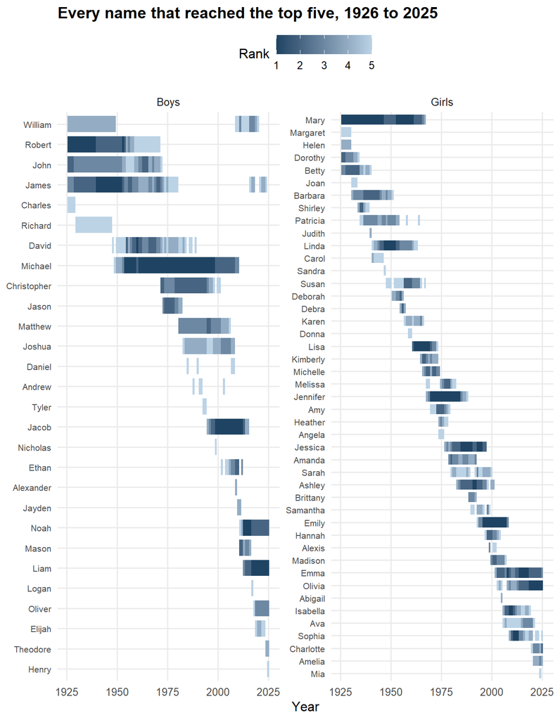

```r
# Order names by the first year they appear, so the chart reads like a timeline
name_order <- names_tidy |>
  group_by(sex, name) |>
  summarise(first = min(year), .groups = "drop")

names_tidy |>
  left_join(name_order, by = c("sex", "name")) |>
  mutate(name = reorder(paste(name, sex), -first)) |>
  ggplot(aes(x = year, y = name, fill = rank)) +
  geom_tile(height = 0.8) +
  facet_wrap(~ sex, scales = "free_y") +
  scale_y_discrete(labels = \(x) str_remove(x, " (Girls|Boys)$")) +
  scale_fill_gradient(low = "#1f4463", high = "#bcd3e6", breaks = 1:5) +
  labs(
    title = "Every name that reached the top five, 1926 to 2025",
    x     = "Year",
    y     = NULL,
    fill  = "Rank"
  ) +
  theme_p2() +
  theme(axis.text.y = element_text(size = 8))
```

```r
top_boy  <- streaks |> filter(sex == "Boys")  |> slice_max(years, n = 1)
top_girl <- streaks |> filter(sex == "Girls") |> slice_max(years, n = 1)
```

**Michael** had the longest run of any name: **62 straight years** in the boys’ top five (1949 to 2010). The longest girls’ run was **Mary** at **42 years** (1926 to 1967). Nine of the ten longest streaks belong to boys’ names, and the four longest (Michael, James, John, and Robert) all lasted more than 45 years. The longest active streak is Emma’s: 24 years running, from 2002 through 2025.

## Analysis 2: Do boys’ and girls’ names turn over at different rates?

```r
turnover_summary <- turnover |>
  group_by(sex) |>
  summarise(
    `Different names in top 5`  = n_distinct(unlist(top5)),
    `New entries, 1927 to 2025` = sum(new_entries, na.rm = TRUE),
    `Avg new entries per year`  = round(mean(new_entries, na.rm = TRUE), 2),
    `Years with no change`      = sum(new_entries == 0, na.rm = TRUE),
    `Median streak (years)`     = median(streaks$years[streaks$sex == first(sex)])
  ) |>
  rename(Sex = sex)

turnover_summary |> kable(caption = "Turnover in the top five, by sex")
```

Turnover in the top five, by sex

| Sex | Different names in top 5 | New entries, 1927 to 2025 | Avg new entries per year | Years with no change | Median streak (years) |
| --- | --- | --- | --- | --- | --- |
| Boys | 28 | 36 | 0.36 | 65 | 4 |
| Girls | 45 | 53 | 0.54 | 53 | 6 |

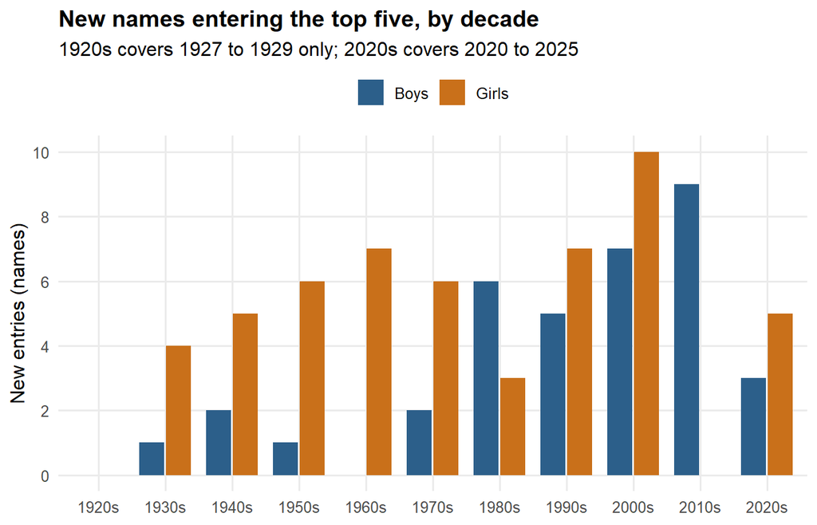

```r
turnover |>
  filter(!is.na(new_entries)) |>
  mutate(decade = paste0(year %/% 10 * 10, "s")) |>
  group_by(sex, decade) |>
  summarise(new_entries = sum(new_entries), .groups = "drop") |>
  ggplot(aes(x = decade, y = new_entries, fill = sex)) +
  geom_col(position = position_dodge(width = 0.8), width = 0.75) +
  scale_fill_manual(values = sex_colors) +
  scale_y_continuous(breaks = seq(0, 10, 2)) +
  labs(
    title    = "New names entering the top five, by decade",
    subtitle = "1920s covers 1927 to 1929 only; 2020s covers 2020 to 2025",
    x        = NULL,
    y        = "New entries (names)",
    fill     = NULL
  ) +
  theme_p2()
```

```r
girls_t <- turnover_summary |> filter(Sex == "Girls")
boys_t  <- turnover_summary |> filter(Sex == "Boys")
by_decade <- turnover |>
  filter(!is.na(new_entries)) |>
  mutate(decade = year %/% 10 * 10) |>
  group_by(sex, decade) |>
  summarise(n = sum(new_entries), .groups = "drop")
boys_2010s  <- by_decade |> filter(sex == "Boys",  decade == 2010) |> pull(n)
girls_2010s <- by_decade |> filter(sex == "Girls", decade == 2010) |> pull(n)
```

Girls’ names turn over faster. Over 100 years, **45 different girls’ names** reached the top five, compared with **28 boys’ names**. Girls’ lists had **53 new entries** versus **36** for boys, and the boys’ top five stayed exactly the same from one year to the next in 65 of 99 years, against 53 for girls.

The decade chart shows that the gap isn’t constant. Through the 1970s, girls’ lists changed much more than boys’. Since the 1980s the pattern has mostly evened out, and in the 2010s it flipped: boys’ names had 9 new entries while the girls’ top five didn’t add a single new name (0 new entries). Emma, Olivia, Sophia, Isabella, and Ava held all five spots for the whole decade.

## Conclusions

- **The most durable names are boys’ names.** Michael stayed in the top five for 62 consecutive years, and four boys’ names lasted more than 45 years. The longest girls’ streak was Mary’s 42 years.
- **Girls’ names turn over more overall.** 45 different girls’ names reached the top five, against 28 boys’ names, and girls had 53 new entries to boys’ 36.
- **The difference has narrowed.** The gap came mostly from the mid-century decades. Recently it reversed, with a frozen girls’ top five in the 2010s while boys’ names churned.
- **Short-lived trends vs. lasting favorites:** the median girls’ streak is 6 years and the median boys’ streak is 4. Boys have more short appearances (names that enter for a few years and leave), next to a handful of extremely long ones.

**Limitations.** The table only has ranks, not birth counts, so it can’t show how close the names were. A name at rank 5 might be just ahead of rank 6 or far ahead. Looking only at the top five also hides names that stayed popular just below it. A name like William can drop to rank 6 for a year and count as a broken streak.

## AI Disclosure and Citation

Claude (Opus 5.5, accessed through claude.ai) helped with this dataset, including copying the SSA table into the CSV and checking it against the page’s own counts, writing the tidying and analysis code, drafting the write-up, and rendering the document to check the results.

Anthropic. (2026). *Claude (Opus 5.5)* [Large language model]. https://claude.ai/. Accessed October 11, 2026.